# TP 8

Hannes Guth

2023-05-09

```r
library(dplyr)
library(fpp3)
library(forecast)
library(data.table)
```

## 1.

**Produce an STL decomposition of the data and describe the trend and seasonality**

```r
setwd("D:/Dokumente/Studium/Master/Université de Genève/Kurse/Forecasting with Business Applications/TP8")

# select the sector "Construction"
data = us_employment %>%
  filter(Title == "Construction")

# create the STL model
STL_dec = data %>%
  model(stl = STL(Employed))

# extract the components and plot them
components(STL_dec)
```

```
## # A dable: 969 x 8 [1M]
## # Key:     Series_ID, .model [1]
## # :        Employed = trend + season_year + remainder
##    Series_ID     .model    Month Employed trend season_year remainder season_a…¹
##    <chr>         <chr>     <mth>    <dbl> <dbl>       <dbl>     <dbl>      <dbl>
##  1 CEU2000000001 stl    1939 Jan      981 1206.      -174.     -51.4       1155.
##  2 CEU2000000001 stl    1939 Feb      970 1206.      -197.     -39.2       1167.
##  3 CEU2000000001 stl    1939 Mrz     1091 1206.      -140.      25.0       1231.
##  4 CEU2000000001 stl    1939 Apr     1181 1206.       -51.2     26.5       1232.
##  5 CEU2000000001 stl    1939 Mai     1286 1206.        28.1     52.0       1258.
##  6 CEU2000000001 stl    1939 Jun     1328 1206.        84.7     37.4       1243.
##  7 CEU2000000001 stl    1939 Jul     1341 1206.       133.       1.54      1208.
##  8 CEU2000000001 stl    1939 Aug     1368 1207.       149.      12.0       1219.
##  9 CEU2000000001 stl    1939 Sep     1342 1207.       140.      -5.68      1202.
## 10 CEU2000000001 stl    1939 Okt     1291 1208.        88.0     -4.99      1203.
## # … with 959 more rows, and abbreviated variable name ¹season_adjust
```

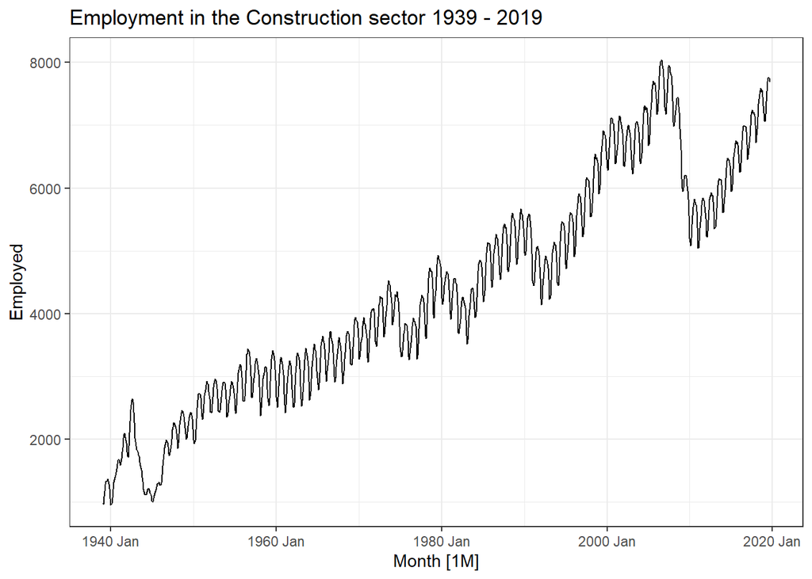

```r
components(STL_dec) %>% as_tsibble() %>% autoplot(Employed) + theme_bw() +
  labs(title = "Employment in the Construction sector 1939 - 2019")
```

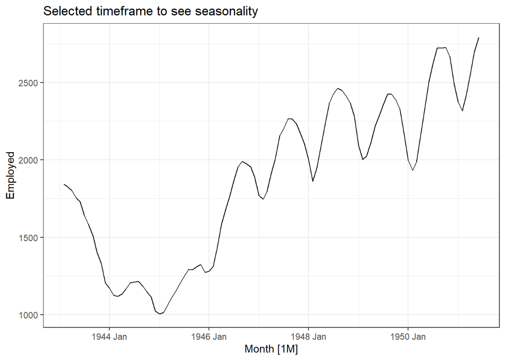

```r
# plot only selected parts to see the seasonality cleary
data_sub = data[50:150,]
STL_dec = data_sub %>%
  model(stl = STL(Employed))
components(STL_dec) %>% as_tsibble() %>% autoplot(Employed) + theme_bw() + labs(title = "Selected timeframe to see seasonality")
```

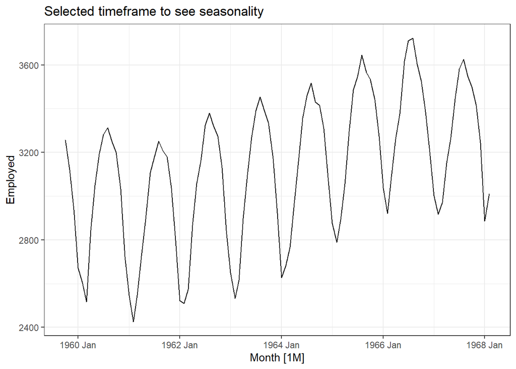

```r
data_sub = data[250:350,]
STL_dec = data_sub %>%
  model(stl = STL(Employed))
components(STL_dec) %>% as_tsibble() %>% autoplot(Employed) + theme_bw() + labs(title = "Selected timeframe to see seasonality")
```

## 2.

**Do the data need transforming? If so, find a suitable transformation**

```r
# retrieve the lambda
lambda = data %>% features(Employed, guerrero) %>% pull(lambda_guerrero)
lambda
```

```
## [1] 0.7616067
```

The lambda is not 0, so the data need transformation.

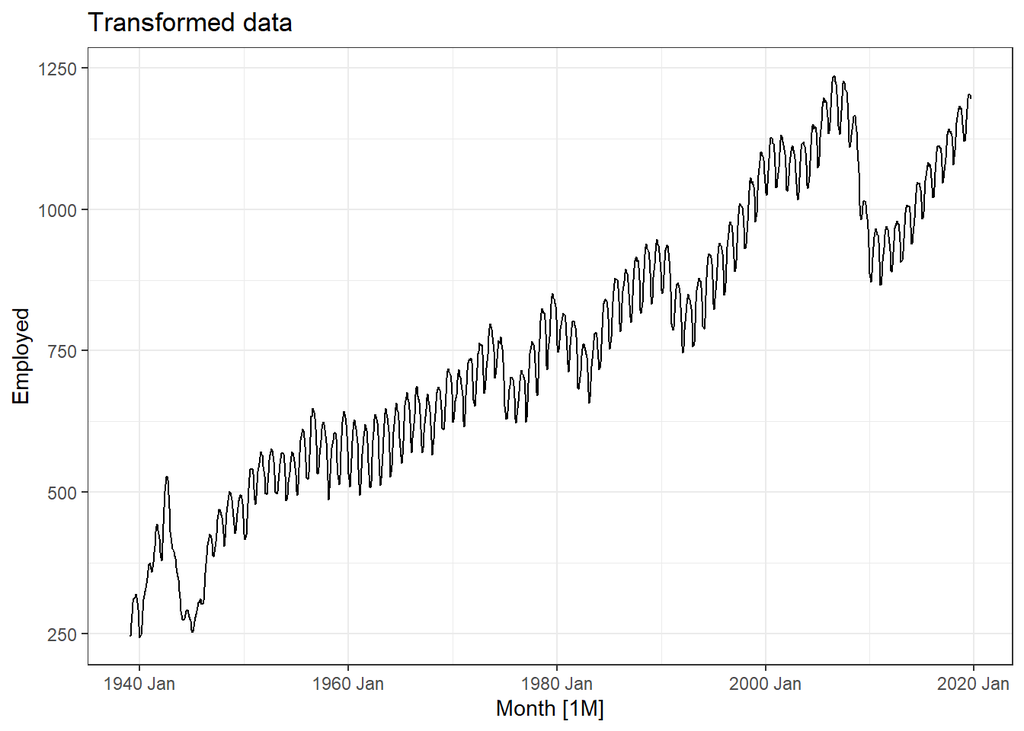

```r
# plot the data
data %>% autoplot(box_cox(Employed, lambda)) + theme_bw() + labs(title = "Transformed data", y = "Employed")
```

## 3.

**Are the data stationary? If not, find an appropriate differencing which yields stationary data.**

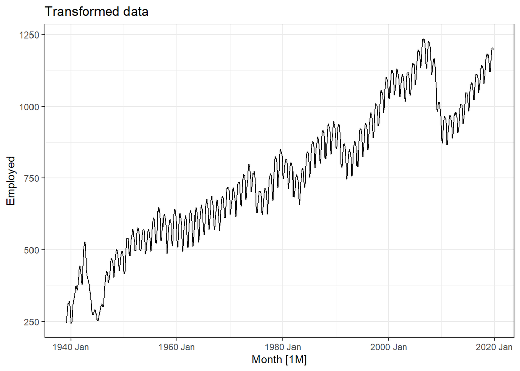

```r
# plot the data again for this page
data %>% autoplot(box_cox(Employed, lambda)) + theme_bw() + labs(title = "Transformed data", y = "Employed")
```

The data are not stationary and require further transformation. The lag is set to 12 for annual seasonality and no differentiation will be done in this step.

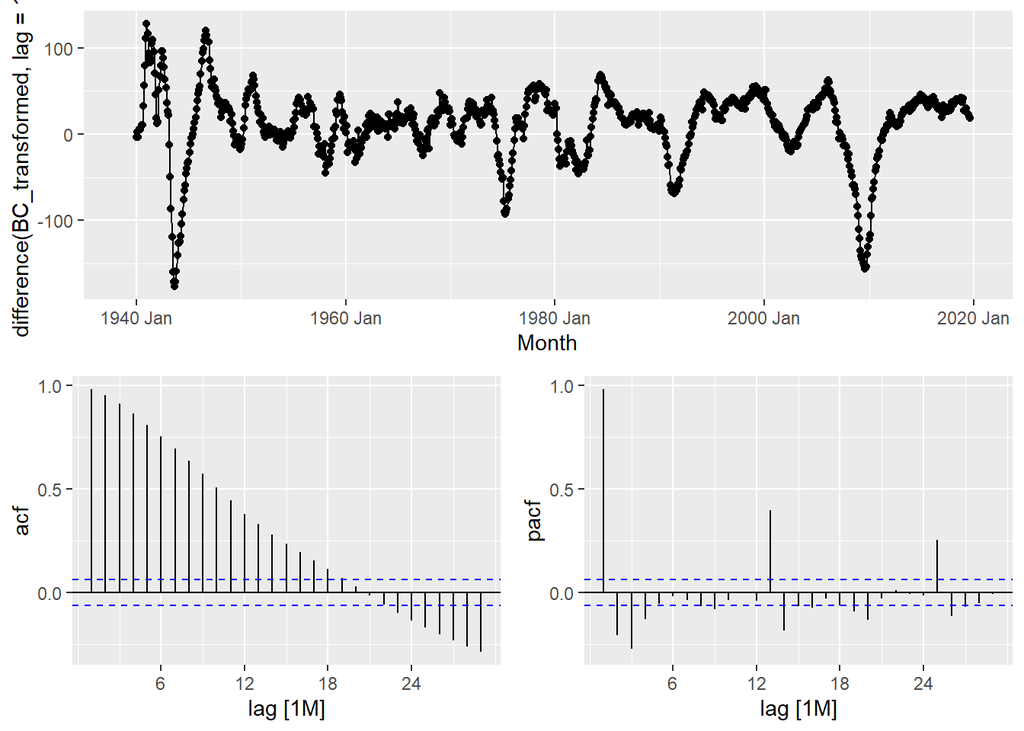

```r
# execute the box-cox transformation
data$BC_transformed = box_cox(data$Employed, lambda)

# plot the residual graph summaries without differencing
data %>% gg_tsdisplay(BC_transformed |>
                           difference(lag=12),
                           plot_type = "partial")
```

From the acf plot, one can see that the data is not yet stationary and needs further transformation, it will be differentiated once.

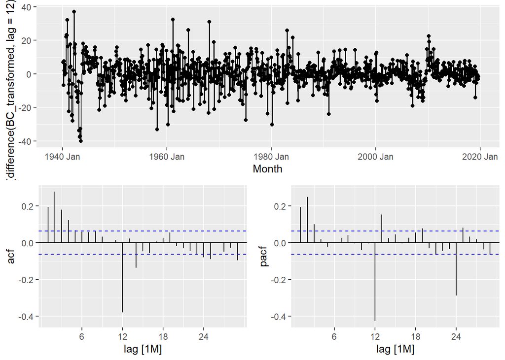

```r
# plot the residual graph summaries with differencing once
data %>% gg_tsdisplay(BC_transformed |>
                           difference(lag = 12) |>
                           difference(difference = 1), plot_type = "partial")
```

The series appears stationary now.

## 4.

**Identify several ARIMA models that might be useful in describing the time series. Which of your models is the best according to their AICc values?**

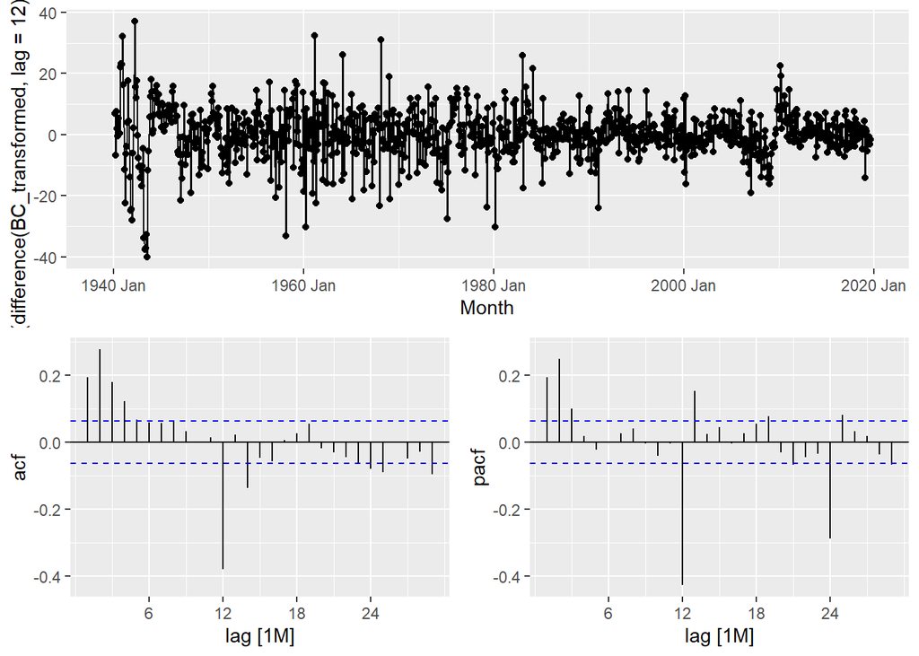

```r
# plot the residual graph summaries with differencing once
data %>% gg_tsdisplay(BC_transformed |>
                           difference(lag = 12) |>
                           difference(difference = 1), plot_type = "partial")
```

Applicable models are estimated as follows, according to the acf and pacf plot.

```r
# fit different ARIMA models
fit = data %>%
  model(
    manual1 = ARIMA(box_cox(Employed, lambda) ~ 0 + pdq(4,1,0) + PDQ(0,1,1)),
    manual2 = ARIMA(box_cox(Employed, lambda) ~ 0 + pdq(0,1,4) + PDQ(3,1,0)),
    manual3 = ARIMA(box_cox(Employed, lambda) ~ 1 + pdq(4,1,0) + PDQ(0,1,1)),
    manual4 = ARIMA(box_cox(Employed, lambda) ~ 1 + pdq(0,1,4) + PDQ(3,1,0)),
    auto = ARIMA(box_cox(Employed, lambda))
  )
# give the summary of the models
glance(fit)
```

```
## # A tibble: 5 × 9
##   Series_ID     .model  sigma2 log_lik   AIC  AICc   BIC ar_roots   ma_roots
##   <chr>         <chr>    <dbl>   <dbl> <dbl> <dbl> <dbl> <list>     <list>
## 1 CEU2000000001 manual1   41.8  -3143. 6299. 6299. 6328. <cpl [4]>  <cpl [12]>
## 2 CEU2000000001 manual2   44.9  -3175. 6365. 6365. 6404. <cpl [36]> <cpl [4]>
## 3 CEU2000000001 manual3   41.8  -3143. 6301. 6301. 6335. <cpl [4]>  <cpl [12]>
## 4 CEU2000000001 manual4   44.9  -3175. 6367. 6367. 6411. <cpl [36]> <cpl [4]>
## 5 CEU2000000001 auto      40.7  -3134. 6285. 6285. 6323. <cpl [4]>  <cpl [13]>
```

The model with the smallest AIC (and AICc) is the automatically chosen model. Only the first manual model comes close to same value.

## 5.

**Estimate the parameters of your best model and do diagnostic testing on the residuals. Do the residuals resemble white noise? If not, try to find another ARIMA model which fits better.**

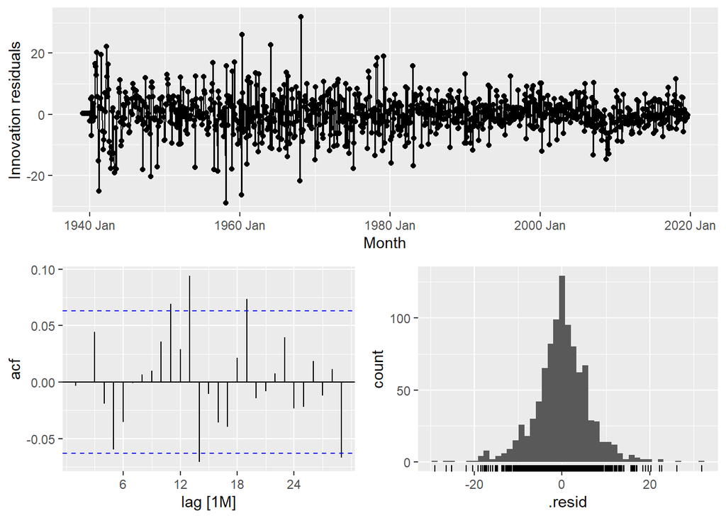

```r
fit %>% select(auto) %>% gg_tsresiduals()
```

## 6.

**Forecast the next 3 years of data. Get the latest figures to check the accuracy of your forecasts.**

```r
# get the new data
cont = fread("continuation.csv")
# change the column names
colnames(cont) = c("Date","True")
# create the forecast
forecast = fit %>% select(auto) %>% fabletools::forecast(h = "3 years")
head(forecast)
```

```
## # A fable: 6 x 4 [1M]
## # Key:     .model [1]
##   .model    Month        Employed .mean
##   <chr>     <mth>          <dist> <dbl>
## 1 auto   2019 Okt  t(N(1194, 41)) 7681.
## 2 auto   2019 Nov  t(N(1181, 97)) 7573.
## 3 auto   2019 Dez t(N(1158, 177)) 7379.
## 4 auto   2020 Jan t(N(1123, 268)) 7086.
## 5 auto   2020 Feb t(N(1123, 370)) 7092.
## 6 auto   2020 Mrz t(N(1134, 481)) 7184.
```

```r
# create the data needed for the plot
Month = c(data$Month, forecast$Month)
Employed = c(data$Employed, cont[(Date > max(data$Month) & Date < (max(data$Month)+37)),]$True)

plotdata = tibble(
  date = Month,
  value = Employed
)

# plot the data
fit %>% select(auto) %>% fabletools::forecast(h = "3 years")
```

```
## # A fable: 36 x 4 [1M]
## # Key:     .model [1]
##    .model    Month        Employed .mean
##    <chr>     <mth>          <dist> <dbl>
##  1 auto   2019 Okt  t(N(1194, 41)) 7681.
##  2 auto   2019 Nov  t(N(1181, 97)) 7573.
##  3 auto   2019 Dez t(N(1158, 177)) 7379.
##  4 auto   2020 Jan t(N(1123, 268)) 7086.
##  5 auto   2020 Feb t(N(1123, 370)) 7092.
##  6 auto   2020 Mrz t(N(1134, 481)) 7184.
##  7 auto   2020 Apr t(N(1157, 599)) 7371.
##  8 auto   2020 Mai t(N(1176, 722)) 7535.
##  9 auto   2020 Jun t(N(1193, 851)) 7678.
## 10 auto   2020 Jul t(N(1199, 984)) 7724.
## # … with 26 more rows
```

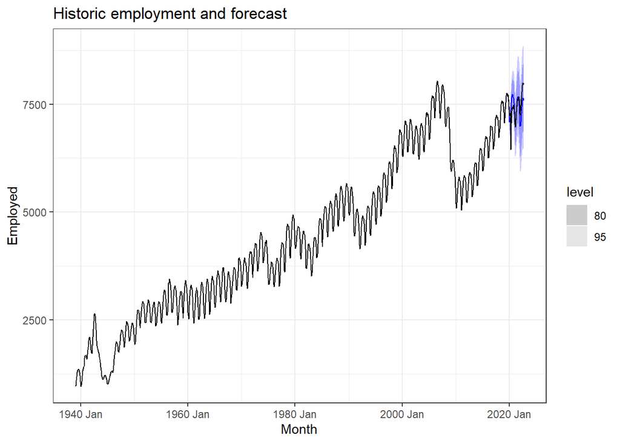

```r
forecast %>% autoplot(plotdata) + theme_bw() + labs(title = "Historic employment and forecast")
```

```r
# calculate the RMSE as a measure for accuracy
accuracydata = data.table("Prediction" = forecast$.mean,
                          "True" = cont[(Date > max(data$Month) & Date < (max(data$Month)+37)),]$True)
RMSE(accuracydata$Prediction, accuracydata$True)
```

```
## [1] 7431.401
```

## 7.

**Eventually, the prediction intervals are so wide that the forecasts are not particularly useful. How many years of forecasts do you think are sufficiently accurate to be usable?**

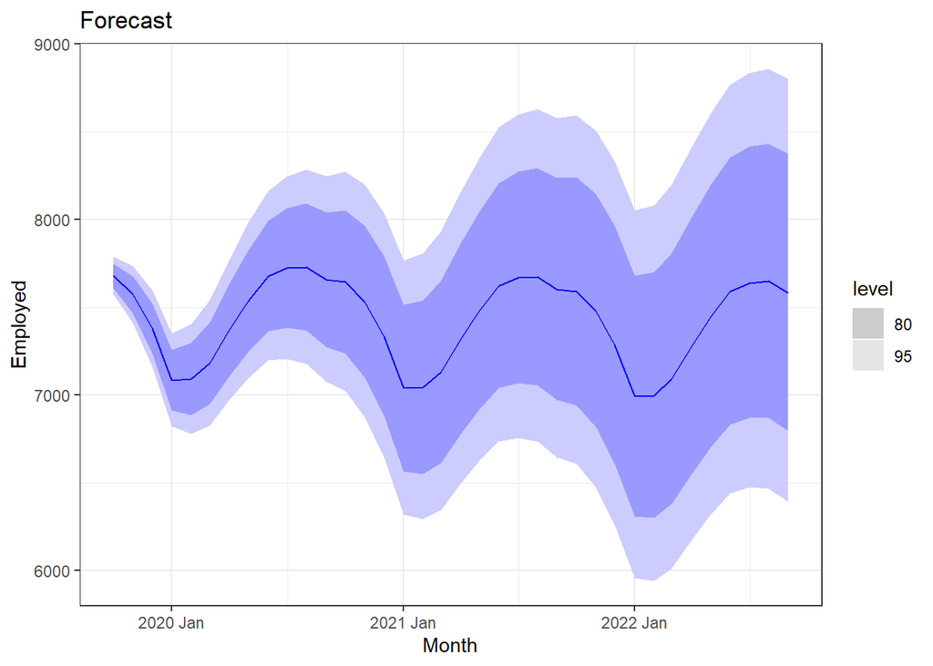

```r
# show the forecast data only
autoplot(forecast) + theme_bw() + labs(title = "Forecast")
```

The forecast is still reasonably wide until approximately January 2021, so around 1.5 years. Afterwards, it becomes too large compared to the actual values.

## References

### Packages

Wickham H, François R, Henry L, Müller K (2022). *dplyr: A Grammar of Data Manipulation*. R package version 1.0.10, https://CRAN.R-project.org/package=dplyr.

Hyndman R (2023). *fpp3: Data for “Forecasting: Principles and Practice” (3rd Edition)*. R package version 0.5, https://CRAN.R-project.org/package=fpp3.

Hyndman R, Athanasopoulos G, Bergmeir C, Caceres G, Chhay L, O’Hara-Wild M, Petropoulos F, Razbash S, Wang E, Yasmeen F (2022). *forecast: Forecasting functions for time series and linear models*. R package version 8.18, https://pkg.robjhyndman.com/forecast/.

Hyndman RJ, Khandakar Y (2008). “Automatic time series forecasting: the forecast package for R.” *Journal of Statistical Software*, *26*(3), 1-22. doi:10.18637/jss.v027.i03 https://doi.org/10.18637/jss.v027.i03.

Dowle M, Srinivasan A (2021). *data.table: Extension of `data.frame`*. R package version 1.14.2, https://CRAN.R-project.org/package=data.table.